# Human Resources Analytics - Employee Churn Predication Analysis

# 4b. Using Other Model

**NOTE:** we will be using two models in this project to measure the accuracy of the different models

The best model performance out of the two (Decision Tree Model and Logistic Regression Model) was **Decision Tree**!

**Remember:** Machines can predict the future, as long as the future doesn't look too different from the past.

**Note: Evaluating the Model**

**Precision and Recall / Class Imbalance**

This dataset is an example of a class imbalance problem because of the skewed distribution of employees who did and did not leave. More skewed the class means that accuracy breaks down.

In this case, evaluating our model’s algorithm based on **accuracy** is the **wrong** thing to measure. We would have to know the different errors that we care about and correct decisions. Accuracy alone does not measure an important concept that needs to be taken into consideration in this type of evaluation: **False Positive** and **False Negative** errors.

**False Positives (Type I Error)**: You predict that the employee will leave, but do not

**False Negatives (Type II Error)**: You predict that the employee will not leave, but does leave

In this problem, what type of errors do we care about more? False Positives or False Negatives?

**Note: Different Ways to Evaluate Classification Models**

1. **Predictive Accuracy:** How many does it get right?
2. **Speed:** How fast does it take for the model to deploy?
3. **Scalability:** Can the model handle large datasets?
4. **Robustness:** How well does the model handle outliers/missing values?
5. **Interpretability:** Is the model easy to understand?

```python
from sklearn.linear_model import LogisticRegression
from sklearn.preprocessing import LabelEncoder
from sklearn.model_selection import train_test_split
from sklearn.metrics import accuracy_score, classification_report, precision_score, recall_score, confusion_matrix, precision_recall_curve
from sklearn.preprocessing import RobustScaler
```

```python
# Create train and test splits
target_name = 'Turnover'
X = df.drop('Turnover', axis=1)
#robust_scaler = RobustScaler()
#X = robust_scaler.fit_transform(X)
y=df[target_name]
X_train, X_test, y_train, y_test = train_test_split(X,y,test_size=0.15, random_state=123, stratify=y)
```

```python
# Check accuracy of Logistic Model
from sklearn.linear_model import LogisticRegression
model = LogisticRegression(penalty='l2', C=1)

model.fit(X_train, y_train)
print ("Logistic accuracy is %2.2f" % accuracy_score(y_test, model.predict(X_test)))
```

```
Logistic accuracy is 0.77
```

```python
# Using 10-fold Cross-Validation to train our Logistic Regression Model
from sklearn import model_selection
from sklearn.linear_model import LogisticRegression

# Set shuffle=True to allow random_state to take effect
kfold = model_selection.KFold(n_splits=10, shuffle=True, random_state=7)

modelCV = LogisticRegression(class_weight="balanced")
scoring = 'roc_auc'

# Perform cross-validation and calculate AUC
results = model_selection.cross_val_score(modelCV, X_train, y_train, cv=kfold, scoring=scoring)
print("AUC: %.3f (%.3f)" % (results.mean(), results.std()))
```

```
AUC: 0.801 (0.035)
```

## Logistic Regression V.S. Decision Tree

```python
# Compare the Logistic Regression Model vs. Decision Tree Model
from sklearn.metrics import roc_auc_score, classification_report
from sklearn.linear_model import LogisticRegression
from sklearn.tree import DecisionTreeClassifier

# Logistic Regression Model
logis = LogisticRegression(class_weight="balanced")
logis.fit(X_train, y_train)

print("\n\n--- Logistic Regression Model ---")
logit_roc_auc = roc_auc_score(y_test, logis.predict(X_test))
print("Logistic Regression AUC = %.2f" % logit_roc_auc)
print(classification_report(y_test, logis.predict(X_test)))

# Decision Tree Model
dtree = DecisionTreeClassifier(
    class_weight="balanced",
    min_weight_fraction_leaf=0.01
)
dtree.fit(X_train, y_train)

print("\n\n--- Decision Tree Model ---")
dt_roc_auc = roc_auc_score(y_test, dtree.predict(X_test))
print("Decision Tree AUC = %.2f" % dt_roc_auc)
print(classification_report(y_test, dtree.predict(X_test)))
```

```
--- Logistic Regression Model ---
Logistic Regression AUC = 0.80
              precision    recall  f1-score   support

           0       0.72      0.76      0.74       186
           1       0.87      0.84      0.86       354

    accuracy                           0.81       540
   macro avg       0.79      0.80      0.80       540
weighted avg       0.82      0.81      0.81       540



--- Decision Tree Model ---
Decision Tree AUC = 0.87
              precision    recall  f1-score   support

           0       0.70      0.96      0.81       186
           1       0.97      0.78      0.87       354

    accuracy                           0.84       540
   macro avg       0.83      0.87      0.84       540
weighted avg       0.88      0.84      0.85       540
```

**Conclusion** The Decision Tree model performs better overall compared to the Logistic Regression model:

1. Higher AUC (0.87 vs. 0.80): The Decision Tree is better at distinguishing between employees who leave and stay.
2. Higher Accuracy (84% vs. 81%): The Decision Tree achieves a higher overall classification accuracy.
3. Higher Precision for Class 1 (0.97 vs. 0.87): The Decision Tree has fewer false positives when predicting employees who leave.
4. Higher Recall for Class 0 (0.96 vs. 0.76): The Decision Tree is significantly better at identifying employees who stay.

However, Logistic Regression has a slight edge in Recall for Class 1 (0.84 vs. 0.78), meaning it identifies more of the employees who leave the company, though it sacrifices some precision for these predictions.

**Recommendation**

1. If identifying employees at risk of leaving (class 1) is more critical, the Decision Tree is recommended due to its overall superior metrics, particularly precision and AUC.
2. However, if the priority is minimizing false negatives for class 1 (ensuring no employees at risk are missed), consider Logistic Regression for its higher recall for class 1.

## ROC Graph

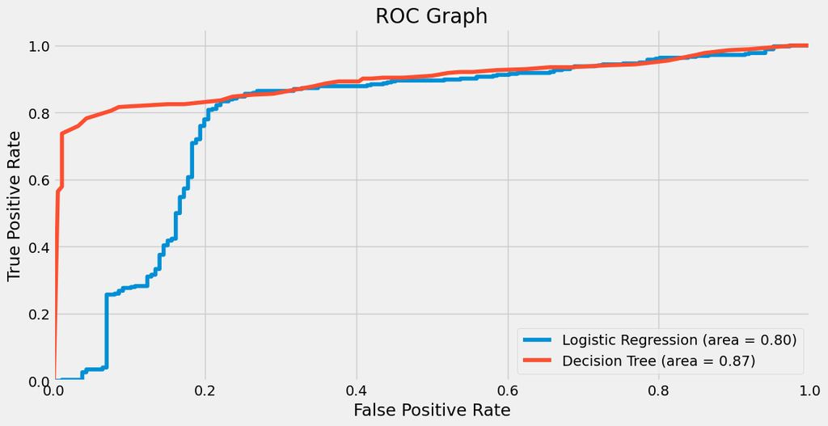

```python
# Create ROC Graph
from sklearn.metrics import roc_curve
fpr, tpr, thresholds = roc_curve(y_test, logis.predict_proba(X_test)[:,1])
rf_fpr, rf_tpr, rf_thresholds = roc_curve(y_test, rf.predict_proba(X_test)[:,1])
dt_fpr, dt_tpr, dt_thresholds = roc_curve(y_test, dtree.predict_proba(X_test)[:,1])
ada_fpr, ada_tpr, ada_thresholds = roc_curve(y_test, ada.predict_proba(X_test)[:,1])

plt.figure()

# Plot Logistic Regression ROC
plt.plot(fpr, tpr, label='Logistic Regression (area = %0.2f)' % logit_roc_auc)

# Plot Decision Tree ROC
plt.plot(dt_fpr, dt_tpr, label='Decision Tree (area = %0.2f)' % dt_roc_auc)

plt.xlim([0.0, 1.0])
plt.ylim([0.0, 1.05])
plt.xlabel('False Positive Rate')
plt.ylabel('True Positive Rate')
plt.title('ROC Graph')
plt.legend(loc="lower right")
plt.show()
```

**FPR (False Positive Rate):** This is the proportion of actual negative cases (class 0: employees who stayed) incorrectly classified as positive (class 1: employees who left). A lower FPR is better. **TPR (True Positive Rate):** Also known as Recall, this is the proportion of actual positive cases (class 1: employees who left) correctly classified as positive. A higher TPR is better.

**Key Components in the Plot**

**Logistic Regression Curve:**

1. Plotted using fpr and tpr for Logistic Regression, with the area under the curve (AUC) displayed in the legend.
2. The higher the curve and the larger the AUC, the better the model is at distinguishing between the two classes (employees staying vs. leaving).

**Decision Tree Curve:**

1. Similarly, the Decision Tree is plotted, and its AUC value is also shown.

**AUC (Area Under the Curve):**

1. The area under the ROC curve is an important metric for evaluating the performance of the model. A model with a higher AUC performs better at classification.
2. An AUC of 0.5 represents a random classifier, while an AUC of 1.0 indicates a perfect model.

**ROC Graph Interpretation:**

1. Logistic Regression and Decision Tree are both plotted on the graph, where: a. The Logistic Regression curve indicates how the model's performance improves as we move from a low threshold to a high threshold for classifying employees who leave. b. The Decision Tree curve shows similar behavior but with potentially different performance based on its configuration.
2. The area under the curve (AUC) displayed in the legend provides an overall summary of model performance. The closer the curve is to the top-left corner (0,1), the better the model is at distinguishing between employees who leave and employees who stay.

**Summary:**

1. Logistic Regression and Decision Tree both demonstrate their ability to differentiate between employees who leave and those who stay by plotting their True Positive Rate versus False Positive Rate at different thresholds.
2. If Decision Tree has a larger AUC, it would indicate better performance in distinguishing between the two classes. Similarly, Logistic Regression will have a smaller or similar AUC if it is not performing as well as the Decision Tree.
3. The ROC curve is crucial because it shows the trade-off between sensitivity (recall) and specificity (1 - FPR), allowing us to assess model performance at various thresholds.

# 5. Interpreting the Data

**Summary:** With all of this information, this is what you should know about this company and why its employees probably left:

1. Employees generally left when they are **underworked** (less than 150hr/month or 6hr/day)
2. Employees generally left when they are **overworked** (more than 250hr/month or 10hr/day)
3. Employees with either **really high or low evaluations** should be taken into consideration for high turnover rate
4. Employees with **low to medium salaries** are the bulk of employee turnover
5. Employees that had **2,6, or 7 project count** was at risk of leaving the company
6. Employee **satisfaction** is the highest indicator for employee turnover.
7. Employee that had **4 and 5 yearsAtCompany** should be taken into consideration for high turnover rate
8. Employee **satisfaction**, **yearsAtCompany**, and **evaluation** were the three biggest factors in determining turnover.

## Potential Solution

**Binary Classification**: Turnover V.S. Non Turnover

**Instance Scoring**: Likelihood of employee responding to an offer/incentive to save them from leaving.

**Need for Application**: Save employees from leaving

In our employee retention problem, rather than simply predicting whether an employee will leave the company within a certain time frame, we would much rather have an estimate of the probability that he/she will leave the company. We would rank employees by their probability of leaving, then allocate a limited incentive budget to the highest probability instances.

Consider employee turnover domain where an employee is given treatment by Human Resources because they think the employee will leave the company within a month, but the employee actually does not. This is a false positive. This mistake could be expensive, inconvenient, and time consuming for both the Human Resources and employee, but is a good investment for relational growth.

Compare this with the opposite error, where Human Resources does not give treatment/incentives to the employees and they do leave. This is a false negative. This type of error is more detrimental because the company lost an employee, which could lead to great setbacks and more money to rehire. Depending on these errors, different costs are weighed based on the type of employee being treated. For example, if it’s a high-salary employee then would we need a costlier form of treatment? What if it’s a low-salary employee? The cost for each error is different and should be weighed accordingly.

**Solution 1:**

- We can rank employees by their probability of leaving, then allocate a limited incentive budget to the highest probability instances.
- OR, we can allocate our incentive budget to the instances with the highest expected loss, for which we'll need the probability of turnover.

**Solution 2:** Develop learning programs for managers. Then use analytics to gauge their performance and measure progress. Some advice:

- Be a good coach
- Empower the team and do not micromanage
- Express interest for team member success
- Have clear vision / strategy for team
- Help team with career development